# Hotel Booking Cancallation Prediction

**Load Data**

Load Hotel_Booking/hotel_bookings.csv file provided on Brightspace.

```python
# Importing Libraries
import seaborn as sb
import pandas as pd
from sklearn.tree import DecisionTreeClassifier
from sklearn.model_selection import train_test_split
from sklearn.metrics import confusion_matrix, classification_report
from sklearn import metrics
from sklearn import preprocessing
from sklearn.preprocessing import StandardScaler
import math


bookings_data = pd.read_csv('hotel_bookings.csv')
```

```python
bookings_data.info()
```

```
<class 'pandas.core.frame.DataFrame'>
RangeIndex: 119390 entries, 0 to 119389
Data columns (total 32 columns):
 #   Column                          Non-Null Count   Dtype
---  ------                          --------------   -----
 0   hotel                           119390 non-null  object
 1   is_canceled                     119390 non-null  int64
 2   lead_time                       119390 non-null  int64
 3   arrival_date_year               119390 non-null  int64
 4   arrival_date_month              119390 non-null  object
 5   arrival_date_week_number        119390 non-null  int64
 6   arrival_date_day_of_month       119390 non-null  int64
 7   stays_in_weekend_nights         119390 non-null  int64
 8   stays_in_week_nights            119390 non-null  int64
 9   adults                          119390 non-null  int64
```

[output cut: 24 more lines]

# 1. Data Pre-processing (25%)

**Drop irrelevant columns**

It will significantly reduce the time and effort you need to invest. As a general guideline, columns containing IDs, dates, or irrelevant information are typically considered redundant and offer little value for predictive analysis.

```python
bookings_data = bookings_data.drop(columns=
                                   ['country',
                                    'reservation_status_date',
                                    'reservation_status',
                                    'arrival_date_day_of_month',
                                    'arrival_date_week_number',
                                    'arrival_date_year',
                                    'arrival_date_month',
                                    'previous_bookings_not_canceled',
                                    'distribution_channel'],axis=1)
```

### Column Drop Explanation:

- Country: Minimal predictive value.
- Reservation Status Date: Redundant date information.
- Reservation Status: Redundant date information.
- Arrival Date Day of Month: Redundant date information.
- Arrival Date Week Number: Redundant date information.
- Arrival Date Year: Redundant date information.
- Arrival Date Month: Redundant date information.
- Previous Bookings Not Canceled: Redundant; covered by existing canceled bookings column.
- Distribution Channel: Offers little additional value; similar information provided by 'market_segment'.

## 1.1 Missing Values (10%)

Identify and handle missing values.

```python
# Getting information of missing values in the data table:

bookings_data.isna().sum()
```

```
hotel                               0
is_canceled                         0
lead_time                           0
stays_in_weekend_nights             0
stays_in_week_nights                0
adults                              0
children                            4
babies                              0
meal                                0
market_segment                      0
is_repeated_guest                   0
previous_cancellations              0
reserved_room_type                  0
assigned_room_type                  0
booking_changes                     0
deposit_type                        0
agent                           16340
company                        112593
days_in_waiting_list                0
customer_type                       0
adr                                 0
required_car_parking_spaces         0
total_of_special_requests           0
dtype: int64
```

#### Company and Agent Drop:

Both columns are ID columns additionally both of them contain large amount of Null values

```python
bookings_data = bookings_data.drop(columns=['company', 'agent'],axis=1)
```

#### Children column fill:

```python
# We are left with the children column only with some null values, we will replace them with 0
bookings_data['children'] = bookings_data['children'].fillna(0)
```

## Unique values

Find out unique values in columns. This will help you in identifying in-consistent data.

```python
# Identifying diffrent hotels in the dataset:
bookings_data.hotel.unique()
```

```
array(['Resort Hotel', 'City Hotel'], dtype=object)
```

```python
# Identifying different types of meal:
bookings_data.meal.value_counts()
```

```
meal
BB           92310
HB           14463
SC           10650
Undefined     1169
FB             798
Name: count, dtype: int64
```

```python
# Finding all the market segments
bookings_data.market_segment.value_counts()
```

```
market_segment
Online TA        56477
Offline TA/TO    24219
Groups           19811
Direct           12606
Corporate         5295
Complementary      743
Aviation           237
Undefined            2
Name: count, dtype: int64
```

```python
# All deposit types:
bookings_data.deposit_type.value_counts()
```

```
deposit_type
No Deposit    104641
Non Refund     14587
Refundable       162
Name: count, dtype: int64
```

```python
# Types of customers:
bookings_data.customer_type.value_counts()
```

```
customer_type
Transient          89613
Transient-Party    25124
Contract            4076
Group                577
Name: count, dtype: int64
```

#### Identifying inconsistent data in numerical values:

```python
bookings_data.adults.value_counts()
```

```
adults
2     89680
1     23027
3      6202
0       403
4        62
26        5
27        2
20        2
5         2
40        1
50        1
55        1
6         1
10        1
Name: count, dtype: int64
```

```python
bookings_data[['stays_in_week_nights','stays_in_weekend_nights']].value_counts()
```

```
stays_in_week_nights  stays_in_weekend_nights
2                     0                          17956
1                     0                          16451
3                     0                          11564
2                     1                           8979
5                     2                           8655
                                                 ...
26                    12                             1
17                    7                              1
25                    9                              1
18                    8                              1
50                    19                             1
Name: count, Length: 85, dtype: int64
```

#### Conclusion:

After identifying unique values, some inconsistencies are found such as:

- bookings with 0 adults
- bookings where there are no days to stay
- Undefined market segments
- Undefined meal types

## 1.2 Removing Inconsistent values and Outliers (10%)

Detecting inconsistencies can be achieved through a variety of methods. Some can be identified by examining unique values within each column, while others may require a solid understanding of the problem domain. Since you might not be an expert in the hotel or hospitality industry, here are some helpful hints:

Hints:

1. Check for incomplete bookings, such as reservations with zero adults, babies, or children.
2. Examine rows with zeros in both 'stays_in_weekend_nights' and 'stays_in_week_nights.'

```python
# Reservations with zero adults

bookings_data = bookings_data.drop(bookings_data[bookings_data['adults'] == 0].index)
```

```python
# Examining rows with zeros in both 'stays_in_weekend_nights' and 'stays_in_week_nights'

bookings_data = bookings_data.drop(bookings_data[(bookings_data['stays_in_weekend_nights'] == 0) & (bookings_data['stays_in_week_nights'] == 0)].index)
```

```python
# After dropping all these columns an index reset is needed
bookings_data.reset_index(drop=True, inplace=True)
```

## Handling Outliers

### Days in Waiting List column

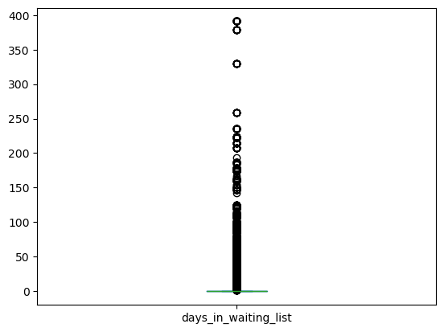

```python
bookings_data.plot(y=['days_in_waiting_list'],kind='box')
# Outliers are vital for enhancing classification accuracy and insights.
```

### Booking Changes Column

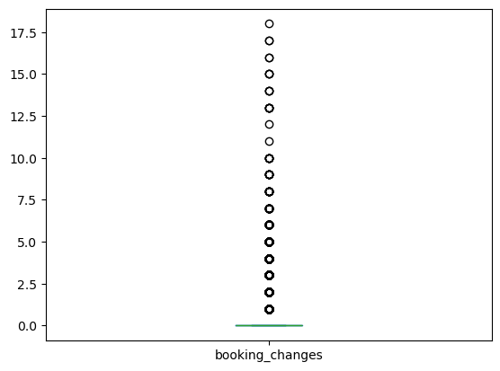

```python
bookings_data.plot(y=['booking_changes'],kind='box')
# Outliers are vital for enhancing classification accuracy and insights.
```

### Previous Cancellations Column

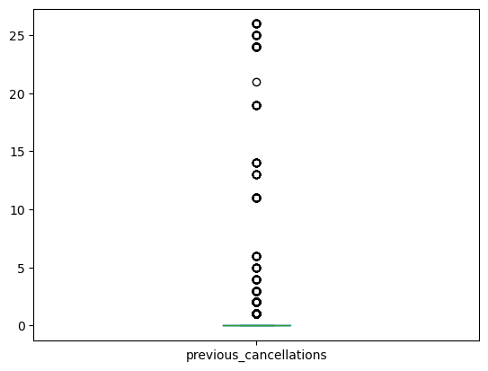

```python
bookings_data.plot(y=['previous_cancellations'],kind='box')
# Outliers are vital for enhancing classification accuracy and insights.
```

### Is Repeated Guest Column

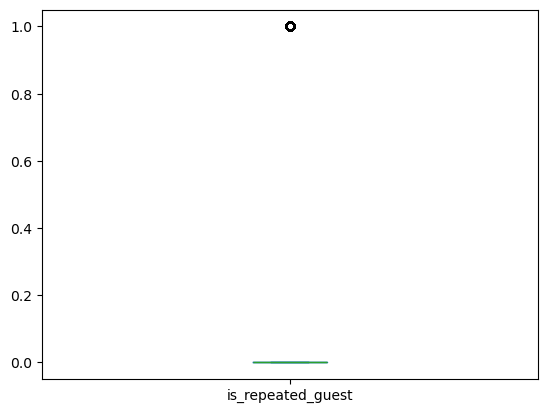

```python
bookings_data.plot(y=['is_repeated_guest'],kind='box')
# Outliers are vital for enhancing classification accuracy and insights.
```

### Babies Column

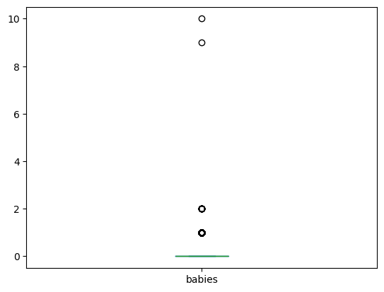

```python
bookings_data.plot(y=['babies'],kind='box')
# Outliers are vital for enhancing classification accuracy and insights.
```

### Children Column

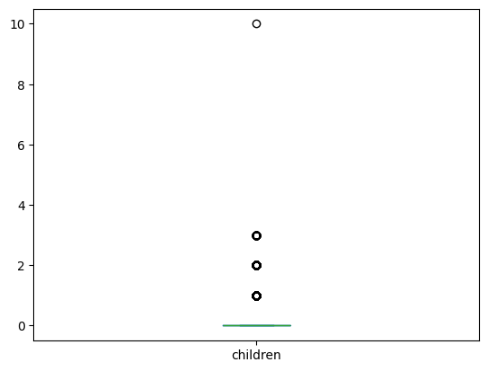

```python
bookings_data.plot(y=['children'],kind='box')
# Outliers are vital for enhancing classification accuracy and insights.
```

### Lead Time Column

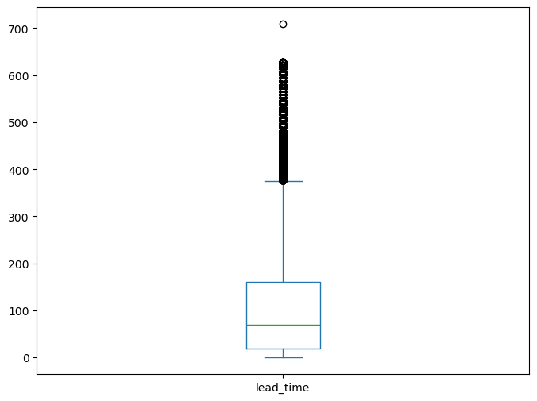

```python
bookings_data.plot(y=['lead_time'],kind='box',figsize=[8,6])
```

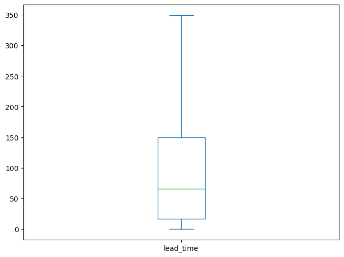

```python
bookings_data = bookings_data.drop(bookings_data[bookings_data['lead_time'] > 349].index)
bookings_data.plot(y=['lead_time'],kind='box',figsize=[8,6])
```

### Stays in Weekend Nights Column

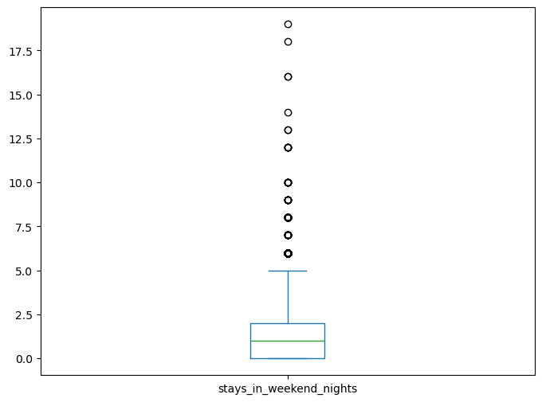

```python
bookings_data.plot(y=['stays_in_weekend_nights'],kind='box',figsize=[8,6])
```

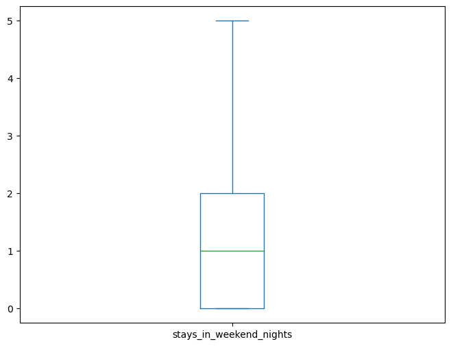

```python
bookings_data = bookings_data.drop(bookings_data[bookings_data['stays_in_weekend_nights'] > 5].index)
bookings_data.plot(y=['stays_in_weekend_nights'],kind='box',figsize=[8,6])
```

### Stays in Week Nights Column

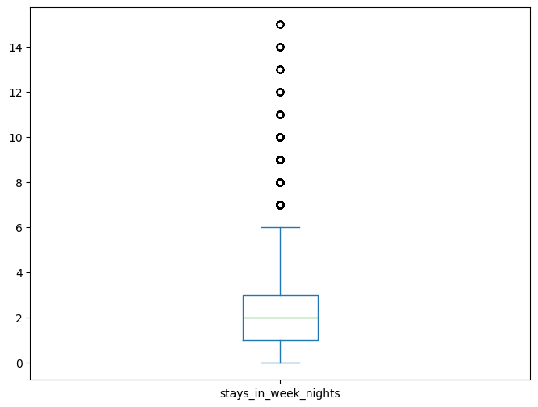

```python
bookings_data.plot(y=['stays_in_week_nights'],kind='box',figsize=[8,6])
```

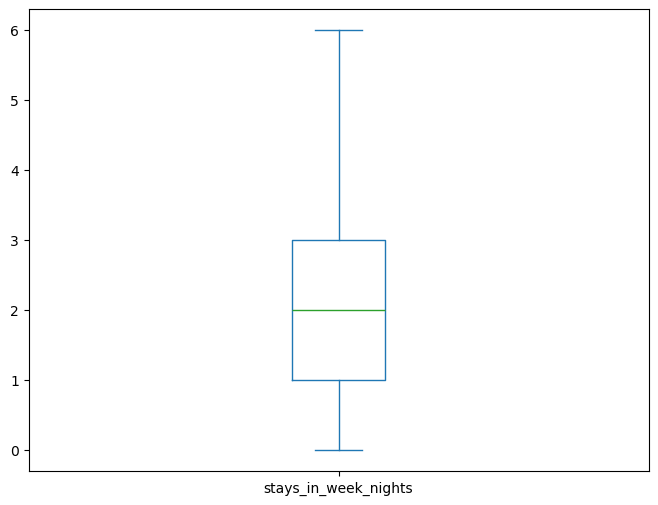

```python
bookings_data = bookings_data.drop(bookings_data[bookings_data['stays_in_week_nights'] > 6].index)
bookings_data.plot(y=['stays_in_week_nights'],kind='box',figsize=[8,6])
```

### ADR Column

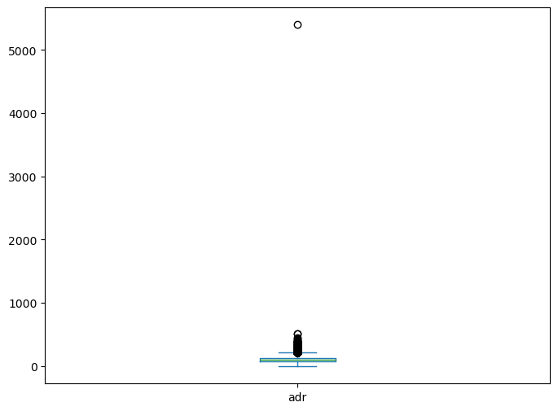

```python
bookings_data.plot(y=['adr'],kind='box',figsize=[8,6])
```

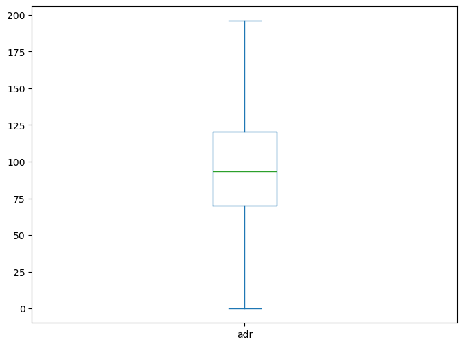

```python
bookings_data = bookings_data.drop(bookings_data[(bookings_data['adr'] > 196) | (bookings_data['adr'] < 0)].index)

bookings_data.plot(y=['adr'],kind='box',figsize=[8,6])
```

### Total Special Requests Column

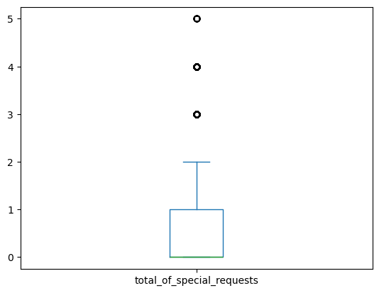

```python
bookings_data.plot(y=['total_of_special_requests'],kind='box')
```

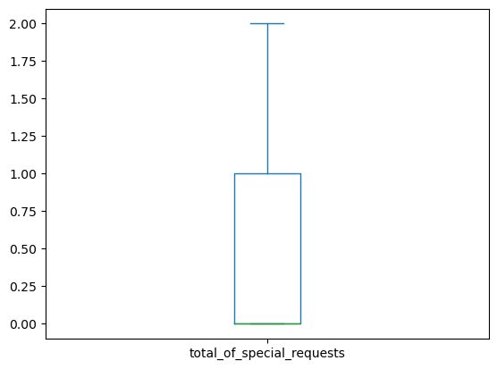

```python
bookings_data = bookings_data.drop(bookings_data[bookings_data['total_of_special_requests'] > 2].index)
bookings_data.plot(y=['total_of_special_requests'],kind='box')
```

### Adults Column

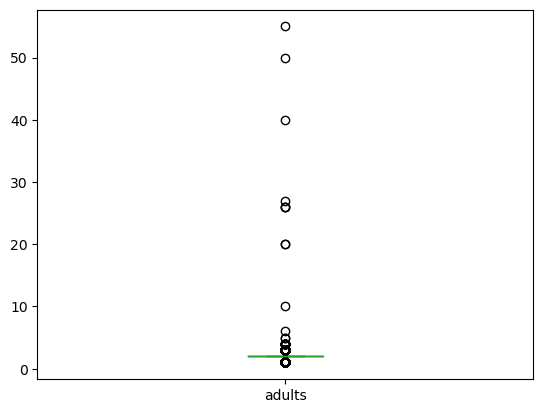

```python
bookings_data.plot(y=['adults'],kind='box')
# Outliers are vital for enhancing classification accuracy and insights.
```

## 1.3 Column data type conversion (5%)

All necessary columns should be correctly converted to appropriate data types.

The "Children" column should be of integer data type, as it represents the count of children and should not contain floating-point values.

```python
bookings_data['children'] = bookings_data['children'].astype('int64')
```

# 2. Exploratory Data Analysis (25%)

You've also been provided with examples of valuable insights that could be of interest to hotel management, including:

- Calculating cancellation percentages for City and Resort hotels.
- Identifying the most frequently ordered meal types.
- Determining the number of returning guests.
- Discovering the most booked room types.
- Exploring correlations between room types and cancellations.

Visualize these insights using three different types of visualizations covered in the practicals, such as:

- Bar graphs
- Pie charts
- Line charts
- Heatmaps

## 2.1. Calculating cancellation percentages for City and Resort hotels.

### Splitting Data for hotels

```python
hotel_name = bookings_data.hotel.unique()
```

```python
city_hotel_data = bookings_data.drop(bookings_data[bookings_data['hotel'] == hotel_name[0]].index)

resort_hotel_data = bookings_data.drop(bookings_data[bookings_data['hotel'] == hotel_name[1]].index)

# This code splits each hotel data into two different datasets so we can treat data dilligently
```

```python
# Getting the is_cancelled column into a variable
resort_is_canceled = resort_hotel_data.is_canceled.value_counts()
```

```python
# Getting the is_cancelled column into a variable
city_is_canceled = city_hotel_data.is_canceled.value_counts()
```

### Solution

To analyze the cancellation percentages for City and Resort hotels, I have compiled the data to highlight the comparative cancellation rates for each type of hotel.

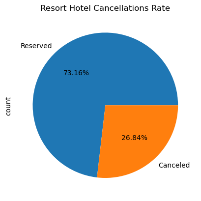

```python
# Resort Hotel Pie

resort_is_canceled.plot(kind='pie',labels={'Reserved','Canceled'},title='Resort Hotel Cancellations Rate',autopct='%.2f%%')
```

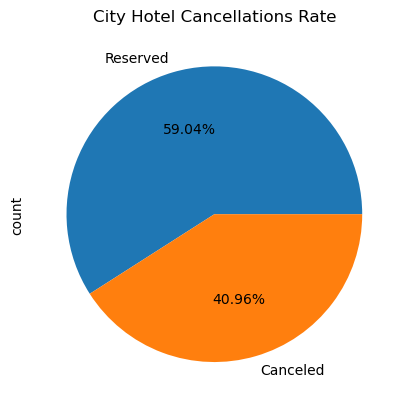

```python
# City Hotel Pie

city_is_canceled.plot(kind='pie',labels={'Reserved','Canceled'},title='City Hotel Cancellations Rate',autopct='%.2f%%')
```

### Conclusion

City Hotels exhibit a cancellation rate of 40.96%, while Resort Hotels show a cancellation rate of 26.84%. This comparison indicates that City Hotels experience a higher cancellation rate than Resort Hotels, which may suggest differing traveler behaviors or market conditions.

## 2.2. Identifying the most frequently ordered meal types.

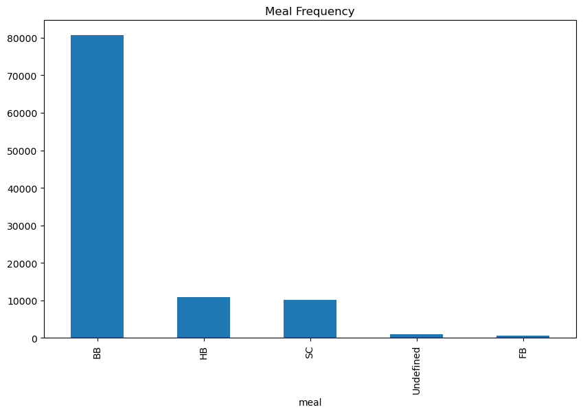

```python
# To solve this task we simply need to show the value counts of the meal column as a bar type chart

bookings_data.meal.value_counts().plot(kind='bar',title='Meal Frequency',figsize=[10,6])
```

### Solution

As observable in the bar chart the Bread and Breakfast is ordered over 80000 times making it the most popular and frequent type of meal.

## 2.3. Determining the number of returning guests.

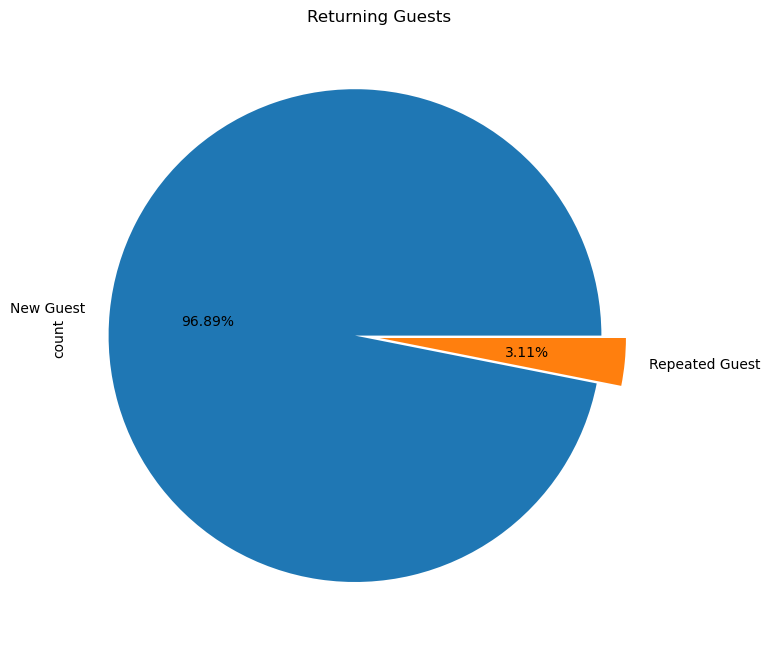

```python
explode = (0.1,0)
bookings_data.is_repeated_guest.value_counts().plot(kind='pie',labels={'New Guest','Repeated Guest'},figsize=[12,8],title='Returning Guests',explode = explode,autopct='%.2f%%')
```

```python
repeat_guests = bookings_data.is_repeated_guest.value_counts()
repeat_guests
```

```
is_repeated_guest
0    100204
1      3218
Name: count, dtype: int64
```

### Solution

The total amount of repeated guests is 3218

## 2.4. Discovering the most booked room types.

```python
room_type_chart = bookings_data.reserved_room_type.value_counts()
room_type_chart
```

```
reserved_room_type
A    77693
D    16410
E     4757
F     1742
G     1104
B      836
C      546
H      329
L        5
Name: count, dtype: int64
```

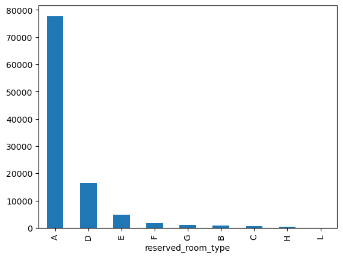

```python
room_type_chart.plot(kind='bar')
```

### Solution

The analysis indicates that Room A is the most frequently booked accommodation option.

## 2.5. Exploring correlations between room types and cancellations.

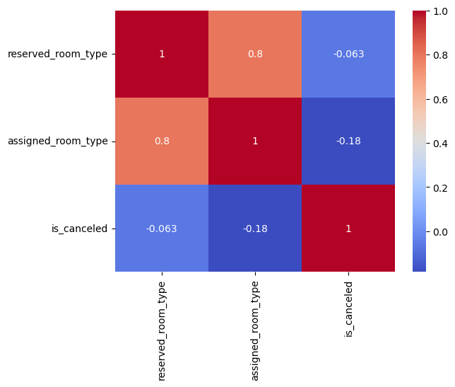

```python
bookings_data['reserved_room_type'] = bookings_data['reserved_room_type'].astype('category').cat.codes
bookings_data['assigned_room_type'] = bookings_data['assigned_room_type'].astype('category').cat.codes


room_cancellations = bookings_data[['reserved_room_type','assigned_room_type','is_canceled']]

corr = room_cancellations.corr().round(3)

sb.heatmap(corr,cmap="coolwarm",annot=True)
```

### Solution

1. Correlation between Assigned Room Type and Reserved Room Type (80%): The strong positive correlation of 80% indicates that there is a significant alignment between the room types that guests are assigned and the types they originally reserved. This suggests that the hotel’s allocation practices are largely effective in matching reservations to actual assignments. Such a high correlation may imply efficient management of room inventory and customer expectations, leading to higher satisfaction rates.
2. Inverse Correlation between Assigned Room Type and Cancellation Status (20%): The 20% inverse correlation between the assigned room type and the cancellation status implies that as the likelihood of a specific room type being assigned increases, the probability of cancellations decreases. Although this correlation is weaker, it still suggests that customers who receive their preferred room types are less likely to cancel their bookings. This insight could inform strategies to minimize cancellations by ensuring that customers are assigned the room types they originally selected.

### Conclusion

In summary, these correlations highlight the importance of aligning assigned and reserved room types to enhance guest satisfaction and reduce cancellations. Further investigation could explore the underlying factors contributing to these relationships and inform strategies for improving booking management.